# Viabilidad 13

límite de 3 operarios, ingresos de 65 k€/mes durante 36 meses

# Enunciado

Una empresa va a ejecutar el proyecto de inversión cuyo cuadro de prelaciones, duración (meses), operarios necesarios y presupuesto (BAC, k€) de cada actividad se adjunta. El coste de cada actividad se desembolsa uniformemente a lo largo de su duración. Cuando el proyecto termina, la instalación genera un flujo de caja neto de 65 k€ al mes durante 36 meses. La empresa descuenta al 12% anual y dispone como máximo de **3 operarios** al mes. Contratar un operario más cuesta **0.5 k€ por mes** mientras dure el proyecto.

1. Calcule la duración y el VAN del proyecto sin tener en cuenta el límite de operarios.

2. Aplique el algoritmo de asignación con el límite de operarios. ¿Cuánto se alarga el proyecto y cuánto cuesta en VAN? Separe el efecto sobre el VAN de los costes y el de los ingresos y explique cuál domina.

3. ¿Compensa contratar un operario más (límite 4)? Construya la tabla de duración y VAN al ampliar el límite en 0, 1, 2 y 3 operarios y compare la mejora del VAN con el coste de contratar (sin descontar, por simplicidad).

4. Calcule el flujo mensual mínimo (umbral del VAN = 0) con y sin el límite. ¿Cuánto sube el umbral por culpa del límite?

Tabla 1: Datos del proyecto

| activity | predecessor | duration | operarios | BAC |
| --- | --- | --- | --- | --- |
| A | --- | 2 | 1 | 200 |
| B | --- | 3 | 1 | 150 |
| C | --- | 1 | 1 | 175 |
| D | A,B,C | 1 | 2 | 175 |
| E | D | 6 | 1 | 125 |
| F | E | 6 | 2 | 125 |
| G | D | 2 | 1 | 175 |
| H | G | 3 | 3 | 175 |
| I | F,H | 5 | 1 | 100 |

# Resolución

## Apartado 1

1. Calcule la duración y el VAN del proyecto sin tener en cuenta el límite de operarios.

Cálculo de los tiempos mínimos y máximos de los nodos del grafo Roy paso a paso. El primer paso muestra el grafo resuelto; a partir del siguiente se calcula desde el principio (avance con los botones):

paso 0 de 24

[figure not shown]

Figura 1: Grafo Roy con el camino crítico (sin límite de operarios)

Tabla 2: Calendario sin límite de recursos (meses)

[figure not shown]

Haz clic en un número de la tabla para ver cómo se calcula.

👆 **Interactivo:** haz clic en cualquier celda de la tabla para ver cómo se calcula (otro clic la deselecciona).

| Actividad | Duración | Inicio más temprano | Fin más temprano | Inicio más tardío | Fin más tardío | H total | H libre | H independiente |
| --- | --- | --- | --- | --- | --- | --- | --- | --- |
| A | 2 | 0 | 2 | 1 | 3 | 1 | 1 | 1 |
| B | 3 | 0 | 3 | 0 | 3 | 0 | 0 | 0 |
| C | 1 | 0 | 1 | 2 | 3 | 2 | 2 | 2 |
| D | 1 | 3 | 4 | 3 | 4 | 0 | 0 | 0 |
| E | 6 | 4 | 10 | 4 | 10 | 0 | 0 | 0 |
| F | 6 | 10 | 16 | 10 | 16 | 0 | 0 | 0 |
| G | 2 | 4 | 6 | 11 | 13 | 7 | 0 | 0 |
| H | 3 | 6 | 9 | 13 | 16 | 7 | 7 | 0 |
| I | 5 | 16 | 21 | 16 | 21 | 0 | 0 | 0 |

El coste mensual de cada actividad es su BAC entre su duración; la fila *Total* del Gantt es el desembolso de cada mes. Cada mes es un periodo: en los meses 1…T el flujo es −desembolso y en los T+1…T+N, +F; la tasa mensual equivalente cumple $(1 + k_m)^{12} = 1 + k$.

[figure not shown]

Figura 2: Gantt de inicios más tempranos con el coste mensual de cada actividad (k€)

|  | 1 | 2 | 3 | 4 | 5 | 6 | 7 | 8 | 9 | 10 | 11 | 12 | 13 | 14 | 15 | 16 | 17 | 18 | 19 | 20 | 21 |
| --- | --- | --- | --- | --- | --- | --- | --- | --- | --- | --- | --- | --- | --- | --- | --- | --- | --- | --- | --- | --- | --- |
| desembolso (k€) | 325.0 | 150.0 | 50.0 | 175.0 | 108.3 | 108.3 | 79.2 | 79.2 | 79.2 | 20.8 | 20.8 | 20.8 | 20.8 | 20.8 | 20.8 | 20.8 | 20.0 | 20.0 | 20.0 | 20.0 | 20.0 |

k mensual = (1 + 0.12)^(1/12) − 1 = 0.9489%. Sin límite: 21 meses de inversión (1400 k€ = Σ BAC) y VAN = 294.4 k€ (valor actual de los ingresos 1619.2 menos el de los desembolsos 1324.8).

Tabla 3: VAN sin y con límite de operarios (van_recursos)

| escenario | duración | VAN costes | VAN ingresos | VAN |
| --- | --- | --- | --- | --- |
| sin límite | 21.0 | 1324.77 | 1619.18 | 294.41 |
| con límite | 24.0 | 1307.81 | 1573.95 | 266.14 |

La librería da lo mismo: sin límite 21 meses y VAN 294.4 k€ (VAN de los ingresos 1619.2, de los costes 1324.8).

## Apartado 2

2. Aplique el algoritmo de asignación con el límite de operarios. ¿Cuánto se alarga el proyecto y cuánto cuesta en VAN? Separe el efecto sobre el VAN de los costes y el de los ingresos y explique cuál domina.

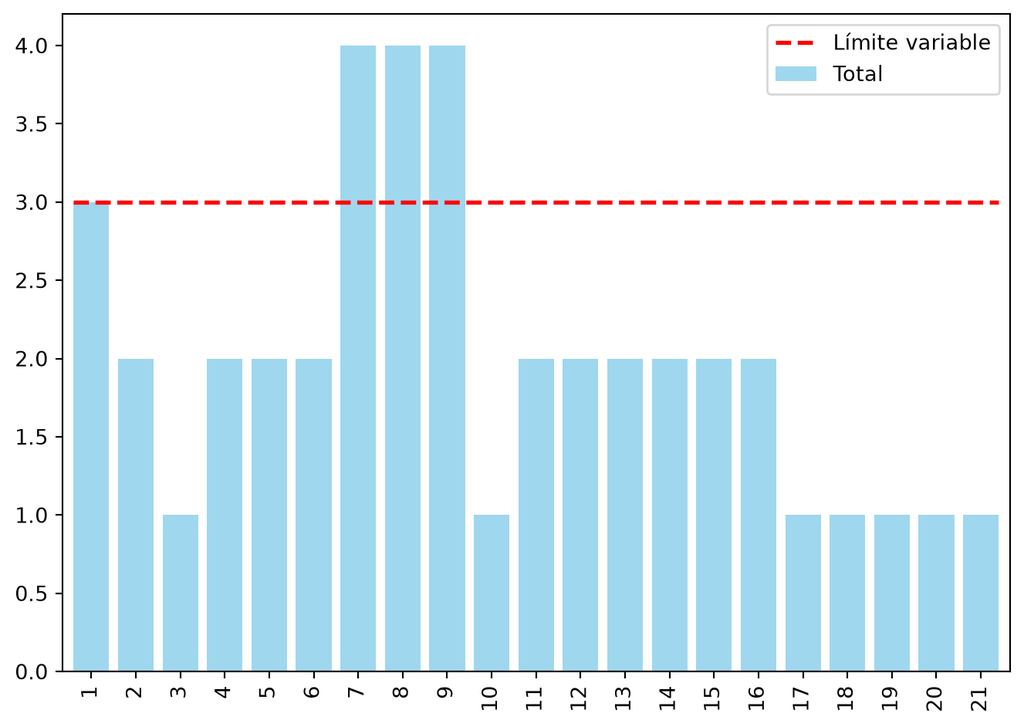

Figura 3: Carga de operarios con los inicios más tempranos frente al límite

El algoritmo de asignación recorre los meses; cada actividad disponible (predecesoras terminadas) empieza, por orden de prioridad (menor inicio más tardío), si caben sus operarios durante toda su duración; si no, espera. Traza mes a mes y Gantt resultante (filas 💤: esperas):

Periodo 1. Empiezan: [‘B’, ‘A’, ‘C’]. Esperan: []

Periodo 4. Empiezan: [‘D’]. Esperan: []

Periodo 5. Empiezan: [‘E’, ‘G’]. Esperan: []

Periodo 7. Empiezan: []. Esperan: [‘H (operarios)’]

Periodo 8. Empiezan: []. Esperan: [‘H (operarios)’]

Periodo 9. Empiezan: []. Esperan: [‘H (operarios)’]

Periodo 10. Empiezan: []. Esperan: [‘H (operarios)’]

Periodo 11. Empiezan: [‘F’]. Esperan: [‘H (operarios)’]

Periodo 12. Empiezan: []. Esperan: [‘H (operarios)’]

Periodo 13. Empiezan: []. Esperan: [‘H (operarios)’]

Periodo 14. Empiezan: []. Esperan: [‘H (operarios)’]

Periodo 15. Empiezan: []. Esperan: [‘H (operarios)’]

Periodo 16. Empiezan: []. Esperan: [‘H (operarios)’]

Periodo 17. Empiezan: [‘H’]. Esperan: []

Periodo 20. Empiezan: [‘I’]. Esperan: []

[figure not shown]

Figura 4: Gantt con el límite de operarios

Tabla 4: Inicio de cada actividad sin y con límite

| activity | A | B | C | D | E | F | G | H | I |
| --- | --- | --- | --- | --- | --- | --- | --- | --- | --- |
| inicio sin límite | 0 | 0 | 0 | 3 | 4 | 10 | 4 | 6 | 16 |
| inicio con límite | 0 | 0 | 0 | 3 | 4 | 10 | 4 | 16 | 19 |
| espera (meses) | 0 | 0 | 0 | 0 | 0 | 0 | 0 | 10 | 0 |

Tabla 5: Desembolso mensual sin y con límite (k€)

|  | 1 | 2 | 3 | 4 | 5 | 6 | 7 | 8 | 9 | 10 | 11 | 12 | 13 | 14 | 15 | 16 | 17 | 18 | 19 | 20 | 21 | 22 | 23 | 24 |
| --- | --- | --- | --- | --- | --- | --- | --- | --- | --- | --- | --- | --- | --- | --- | --- | --- | --- | --- | --- | --- | --- | --- | --- | --- |
| sin límite | 325.0 | 150.0 | 50.0 | 175.0 | 108.3 | 108.3 | 79.2 | 79.2 | 79.2 | 20.8 | 20.8 | 20.8 | 20.8 | 20.8 | 20.8 | 20.8 | 20.0 | 20.0 | 20.0 | 20.0 | 20.0 | 0.0 | 0.0 | 0.0 |
| con límite | 325.0 | 150.0 | 50.0 | 175.0 | 108.3 | 108.3 | 20.8 | 20.8 | 20.8 | 20.8 | 20.8 | 20.8 | 20.8 | 20.8 | 20.8 | 20.8 | 58.3 | 58.3 | 58.3 | 20.0 | 20.0 | 20.0 | 20.0 | 20.0 |

Con 3 operarios el proyecto dura 24 meses (+3): los ingresos empiezan en el mes 25 en vez del 22. VAN = 266.1 k€ (la librería: 266.1) frente a 294.4 sin límite: -28.3 k€. Efecto en los ingresos: -45.2 k€ (se cobran más tarde); en los costes: 17.0 k€ (las actividades que esperan se pagan más tarde y el coste se descuenta más). El retraso de los ingresos domina.

## Apartado 3

3. ¿Compensa contratar un operario más (límite 4)? Construya la tabla de duración y VAN al ampliar el límite en 0, 1, 2 y 3 operarios y compare la mejora del VAN con el coste de contratar (sin descontar, por simplicidad).

Tabla 6: Duración y VAN al ampliar el límite de operarios

| unidades de más | duración | VAN | mejora de VAN | coste de contratar | VAN neto de contratar |
| --- | --- | --- | --- | --- | --- |
| 0 | 24.0 | 266.14 | NaN | 0.0 | 266.14 |
| 1 | 21.0 | 294.41 | 28.27 | 10.5 | 283.91 |
| 2 | 21.0 | 294.41 | 0.00 | 21.0 | 273.41 |
| 3 | 21.0 | 294.41 | 0.00 | 31.5 | 262.91 |

La mejor opción es ampliar el límite en 1 operario(s): VAN neto 283.9 k€ frente a 266.1 k€ sin ampliar. Se compara la mejora del VAN por adelantar los ingresos con lo que cuesta mantener a los operarios todo el proyecto.

## Apartado 4

4. Calcule el flujo mensual mínimo (umbral del VAN = 0) con y sin el límite. ¿Cuánto sube el umbral por culpa del límite?

Flujo mensual mínimo: 53.18 k€ sin límite y 54.01 k€ con límite (+0.83 k€ al mes): el límite exige más ingresos para recuperar lo mismo.